# Unsupervised_Learning_Methods

```python
import pandas as pd
import numpy as np
import matplotlib.pyplot as plt
import seaborn as sns
from sklearn.preprocessing import StandardScaler
from sklearn.cluster import KMeans
from sklearn.metrics import silhouette_score
```

```python
columns_to_include = [
    'country', 'year', 'gdp', 'co2',
    'coal_co2', 'oil_co2', 'gas_co2', 'cement_co2', 'flaring_co2',
    'co2_per_capita', 'co2_per_gdp', 'share_global_co2',
    'methane_per_capita', 'nitrous_oxide_per_capita',
    'total_ghg_excluding_lucf', 'total_ghg', 'temperature_change_from_co2'
]

df = pd.read_csv("owid-co2-data.csv")
df = df[df['iso_code'].str.len() == 3]
df = df[df['year'].between(2000, 2022)]
df = df.dropna(subset=columns_to_include)

output_path = "Filtered_CO2.csv"
df[columns_to_include].to_csv(output_path, index=False)
print(" Saved:", output_path)
print(" Shape:", df[columns_to_include].shape)

# Verification preview
print("\n First 5 rows:")
print(df[columns_to_include].head())
```

```
 Saved: Filtered_CO2.csv
 Shape: (2286, 17)

 First 5 rows:
         country  year           gdp    co2  coal_co2  oil_co2  gas_co2  \
250  Afghanistan  2000  1.128379e+10  1.047     0.004    0.788    0.224
251  Afghanistan  2001  1.102127e+10  1.069     0.070    0.762    0.209
252  Afghanistan  2002  1.880487e+10  1.341     0.055    0.727    0.547
253  Afghanistan  2003  2.107434e+10  1.560     0.092    0.992    0.466
254  Afghanistan  2004  2.233257e+10  1.237     0.092    0.909    0.227

     cement_co2  flaring_co2  co2_per_capita  co2_per_gdp  share_global_co2  \
250       0.010        0.022           0.052        0.093             0.004
251       0.007        0.022           0.053        0.097             0.004
252       0.011        0.000           0.063        0.071             0.005
253       0.010        0.000           0.069        0.074             0.006
254       0.010        0.000           0.053        0.055             0.004

     methane_per_capita  nitrous_oxide_per_capita  total_ghg_excluding_lucf  \
250               0.578                     0.160                     4.521
251               0.511                     0.141                     4.670
252               0.583                     0.154                     5.132
253               0.566                     0.151                     5.521
254               0.548                     0.145                     5.354

     total_ghg  temperature_change_from_co2
250     16.955                          0.0
251     15.772                          0.0
252     20.735                          0.0
253     21.423                          0.0
254     20.057                          0.0
```

```python
def fit_svd(X, M=1):
    U, s, V = np.linalg.svd(X, full_matrices=False)
    return U[:, :M] @ (np.diag(s[:M]) @ V[:M, :])
```

```python
df = pd.read_csv("Filtered_CO2.csv")
features = [
    'gdp', 'co2', 'coal_co2', 'oil_co2', 'gas_co2',
    'cement_co2', 'flaring_co2', 'co2_per_capita',
    'co2_per_gdp', 'share_global_co2',
    'methane_per_capita', 'nitrous_oxide_per_capita',
    'total_ghg_excluding_lucf', 'total_ghg',
    'temperature_change_from_co2'
]
X = df[features].values
scaler = StandardScaler()
X_scaled = scaler.fit_transform(X)
```

```python
print("Shape of df:", df.shape)
print("Shape of X_scaled:", X_scaled.shape)
```

```
Shape of df: (2286, 17)
Shape of X_scaled: (2286, 15)
```

```
Shape of U: (2286, 15)
Shape of S: (15,)
Shape of Vt: (15, 15)
```

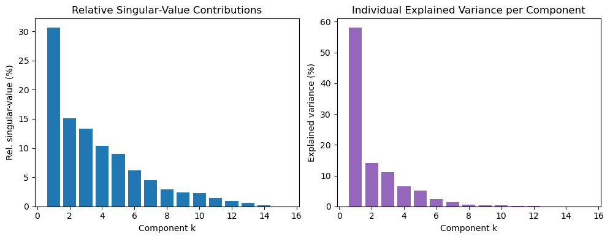

```python
U, S, Vt = np.linalg.svd(X_scaled, full_matrices=False)

print("Shape of U:", U.shape)
print("Shape of S:", S.shape)
print("Shape of Vt:", Vt.shape)
explained_var = (S**2) / np.sum(S**2)
rel_sv = S / np.sum(S)

fig, axes = plt.subplots(1, 2, figsize=(10,4))
axes[0].bar(np.arange(1,len(S)+1), rel_sv*100)
axes[0].set_xlabel("Component k")
axes[0].set_ylabel("Rel. singular-value (%)")
axes[0].set_title("Relative Singular‐Value Contributions")

axes[1].bar(np.arange(1,len(S)+1), explained_var*100, color='C4')
axes[1].set_xlabel("Component k")
axes[1].set_ylabel("Explained variance (%)")
axes[1].set_title("Individual Explained Variance per Component")
plt.tight_layout()
plt.show()
```

These plots show how much each SVD component “weighs” in your data:

Left: the share of total singular‐value mass , with the first component alone contributing about 30 % and the next few rapidly declining.

Right: the analogous variance‐explained , where the first component captures nearly 60 % of the variance, the second ~14 %, the third ~11 %, etc., implying that just the top 3–5 components recover most of the structure.

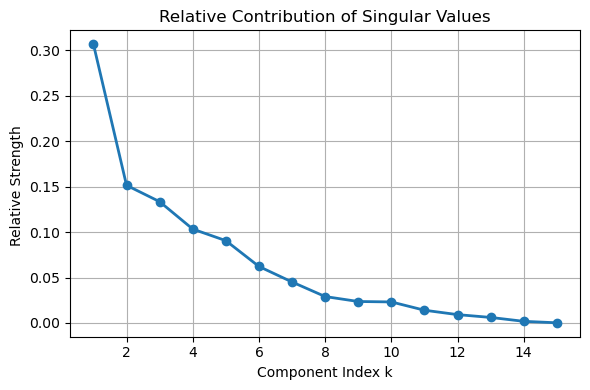

```python
rel_strength = S / S.sum()
plt.figure(figsize=(6,4))
plt.plot(np.arange(1, len(S)+1), rel_strength, 'o-', linewidth=2)
plt.xlabel("Component Index k")
plt.ylabel("Relative Strength ")
plt.title("Relative Contribution of Singular Values")
plt.grid(True)
plt.tight_layout()
plt.show()
```

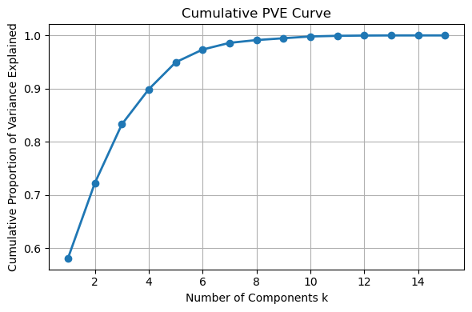

```python
# 2) Cumulative PVE curve
explained_var = (S**2) / np.sum(S**2)
cum_pve = np.cumsum(explained_var)

plt.figure(figsize=(6,4))
plt.plot(np.arange(1, len(cum_pve)+1), cum_pve, 'o-', linewidth=2)
plt.xlabel("Number of Components k")
plt.ylabel("Cumulative Proportion of Variance Explained")
plt.title("Cumulative PVE Curve")
plt.grid(True)
plt.tight_layout()
plt.show()
```

This plot shows how the total variance in your standardized emission data accumulates as you include more SVD components:

By component 4 you already explain about 90 % of the variance, and by component 8 you’re up near 98 %. It confirms that a low‐dimensional embedding (e.g. k=5–8) captures nearly all the meaningful structure in the full 15-feature space.

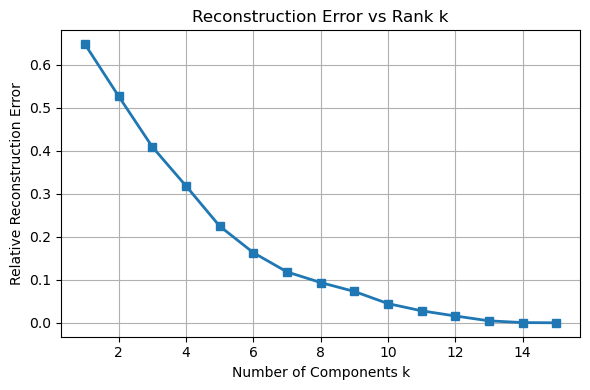

```python
errors = []
normX = np.linalg.norm(X_scaled, 'fro')
for k in range(1, len(S)+1):
    Xk = U[:, :k] @ np.diag(S[:k]) @ Vt[:k, :]
    errors.append(np.linalg.norm(X_scaled - Xk, 'fro') / normX)

plt.figure(figsize=(6,4))
plt.plot(np.arange(1, len(errors)+1), errors, 's-', linewidth=2)
plt.xlabel("Number of Components k")
plt.ylabel("Relative Reconstruction Error")
plt.title("Reconstruction Error vs Rank k")
plt.grid(True)
plt.tight_layout()
plt.show()
```

```python
def matrix_completion(X, mask, M=1, max_iter=50, tol=1e-6, verbose=False):
    """
    Fills in missing values using low-rank SVD.
    Starts with column means, then refines iteratively.
    Stops when improvement is small or max iterations reached.
    Returns completed matrix, error history, and iteration count.
    """
    Xhat = X.copy()
    # initialize missing with column means
    col_means = np.nanmean(X, axis=0)
    inds = np.where(mask)
    Xhat[inds] = np.take(col_means, inds[1])
    rel_errors = []
    mss0 = np.mean(np.square(X[~mask]))
    mssold = mss0
    for it in range(max_iter):
        Xapp = fit_svd(Xhat, M=M)
        Xhat[mask] = Xapp[mask]
        mss = np.mean(np.square(X[~mask] - Xapp[~mask]))
        rel_err = (mssold - mss) / mss0
        rel_errors.append(rel_err)
        if verbose:
            print(f"Iter {it+1}: mss={mss:.6f}, rel_err={rel_err:.6f}")
        if rel_err < tol:
            break
        mssold = mss
    return Xhat, rel_errors, it+1
```

```python
def run_co2_experiment(missing_fractions, M_values, num_reps=5):
    """
    For each missing‐data fraction and each truncation rank M, randomly mask
    that fraction of X_scaled, perform matrix‐completion, and record RMSE.
    Prints a summary table of average RMSEs before plotting.
    """
    n, p = X_scaled.shape
    results = np.zeros((len(missing_fractions), len(M_values)))

    for i, frac in enumerate(missing_fractions):
        for rep in range(num_reps):
            # create random mask
            mask = np.zeros((n, p), dtype=bool)
            idx = np.random.choice(n * p, int(frac * n * p), replace=False)
            mask[np.unravel_index(idx, (n, p))] = True

            X_missing = X_scaled.copy()
            X_missing[mask] = np.nan

            for j, M in enumerate(M_values):
                X_hat, _, _ = matrix_completion(X_missing, mask, M=M)
                rmse = np.sqrt(np.mean((X_scaled[mask] - X_hat[mask])**2))
                results[i, j] += rmse

        # average over repetitions
        results[i, :] /= num_reps

    # build and print summary table
    df_results = pd.DataFrame(
        results,
        index=[f"{int(f*100)}%" for f in missing_fractions],
        columns=[f"M={M}" for M in M_values]
    )
    print("\nAverage Approximation Error (RMSE):")
    print(df_results)

    # plot the RMSE curves
    plt.figure(figsize=(8, 5))
    for j, M in enumerate(M_values):
        plt.plot(missing_fractions, results[:, j], marker='o', label=f"M={M}")
    plt.xlabel("Fraction Missing")
    plt.ylabel("RMSE of Reconstruction")
    plt.title("CO₂ Matrix Completion: RMSE vs Missing Fraction")
    plt.legend(title='Rank M', bbox_to_anchor=(1.02, 1), loc='upper left')
    plt.grid(True)
    plt.tight_layout()
    plt.show()

    return results, df_results
```

```
Average Approximation Error (RMSE):
          M=1       M=2       M=3       M=4       M=5       M=6       M=7  \
5%   0.687479  0.647983  0.549417  0.697632  0.712228  0.691874  0.657878
10%  0.686929  0.640934  0.535658  0.806119  0.714964  0.632033  0.632445
15%  0.701640  0.654068  0.564727  0.732517  0.761436  0.656248  0.638973
20%  0.693103  0.662375  0.577002  0.744964  0.809934  0.662522  0.649092
25%  0.677585  0.677115  0.614120  0.731438  0.775149  0.634484  0.627744
30%  0.697442  0.671871  0.632696  0.746105  0.773166  0.641914  0.649178

          M=8
5%   0.631937
10%  0.629393
15%  0.652794
20%  0.642173
25%  0.631252
30%  0.666814
```

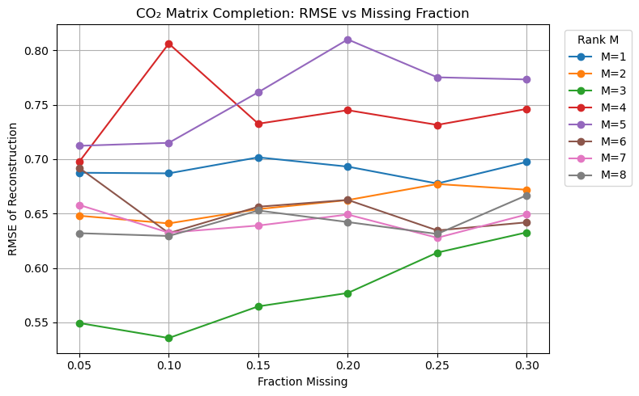

```python
missing_fractions = np.arange(0.05, 0.35, 0.05)
M_values = [1, 2, 3, 4, 5, 6, 7, 8]
results, summary_df = run_co2_experiment(missing_fractions, M_values)
```

```python
for i in range(8):
    component_weights = Vt[i]
    top_indices = np.argsort(np.abs(component_weights))[::-1][:5]
    print(f"\nTop features for Component {i+1}:")
    for idx in top_indices:
        print(f"  {features[idx]} ({component_weights[idx]:.3f})")
```

```
Top features for Component 1:
  co2 (0.333)
  total_ghg_excluding_lucf (0.333)
  share_global_co2 (0.332)
  total_ghg (0.330)
  gdp (0.328)

Top features for Component 2:
  co2_per_capita (0.567)
  methane_per_capita (0.519)
  co2_per_gdp (0.311)
  flaring_co2 (0.292)
  cement_co2 (-0.239)

Top features for Component 3:
  flaring_co2 (0.427)
  cement_co2 (-0.381)
  gas_co2 (0.370)
  methane_per_capita (-0.346)
  coal_co2 (-0.303)

Top features for Component 4:
  nitrous_oxide_per_capita (-0.886)
  co2_per_gdp (0.440)
  flaring_co2 (0.104)
  gdp (-0.046)
  methane_per_capita (-0.044)

Top features for Component 5:
  co2_per_gdp (0.755)
  nitrous_oxide_per_capita (0.409)
  methane_per_capita (-0.408)
  co2_per_capita (-0.243)
  flaring_co2 (0.147)

Top features for Component 6:
  flaring_co2 (0.701)
  methane_per_capita (0.346)
  co2_per_capita (-0.336)
  oil_co2 (-0.325)
  cement_co2 (0.264)

Top features for Component 7:
  co2_per_capita (0.632)
  methane_per_capita (-0.559)
  flaring_co2 (0.309)
  temperature_change_from_co2 (-0.237)
  co2_per_gdp (-0.205)

Top features for Component 8:
  gas_co2 (0.777)
  oil_co2 (-0.454)
  flaring_co2 (-0.242)
  cement_co2 (0.238)
  total_ghg (-0.212)
```

```python
# 1) choose k based on PVE:

pc_coords  = U[:, :8]
```

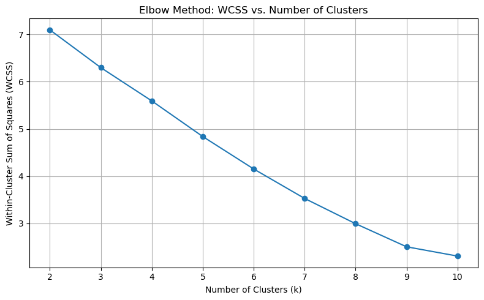

```python
# 1) Search over a range of cluster counts
Ks = range(2, 11)
inertias = []
sil_scores = []

for k in Ks:
    km = KMeans(n_clusters=k, n_init=10, random_state=42)
    labels = km.fit_predict(pc_coords)
    inertias.append(km.inertia_)
    sil_scores.append(silhouette_score(pc_coords, labels))

# 2) Plot inertia (elbow method)
plt.figure(figsize=(8,5))
plt.plot(list(Ks), inertias, marker='o', linestyle='-')
plt.title("Elbow Method: WCSS vs. Number of Clusters")
plt.xlabel("Number of Clusters (k)")
plt.ylabel("Within-Cluster Sum of Squares (WCSS)")
plt.xticks(Ks)
plt.grid(True)
plt.tight_layout()
plt.show()
```

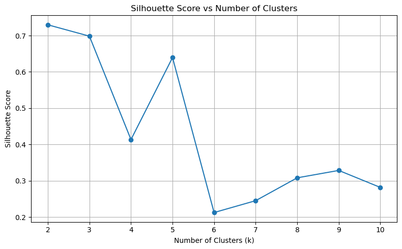

```python
plt.figure(figsize=(8, 5))
plt.plot(list(Ks), sil_scores, marker='o', linestyle='-')
plt.title("Silhouette Score vs Number of Clusters")
plt.xlabel("Number of Clusters (k)")
plt.ylabel("Silhouette Score")
plt.xticks(Ks)
plt.grid(True)
plt.tight_layout()
plt.show()
```

```python
optimal_k_svd  = 5
labels = KMeans(n_clusters=5, n_init=10, random_state=42).fit_predict(pc_coords)
df['cluster'] = labels
```

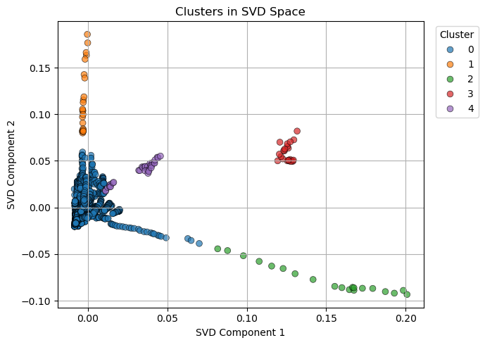

```python
plt.figure(figsize=(7,5))
sns.scatterplot(x=pc_coords[:,0], y=pc_coords[:,1], hue=labels, palette='tab10', s=40, edgecolor='k', alpha=0.7)
plt.xlabel("SVD Component 1")
plt.ylabel("SVD Component 2")
plt.title("Clusters in SVD Space")
plt.legend(title="Cluster", bbox_to_anchor=(1.02,1), loc="upper left")
plt.grid(True)
plt.tight_layout()
plt.show()
```

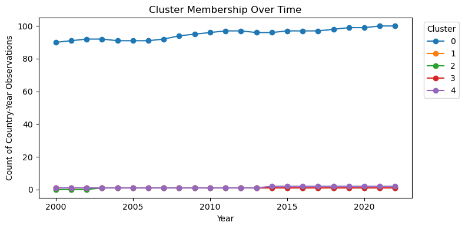

```python
meta = df[['country','year','cluster']]
ts = meta.groupby(['year','cluster']).size().unstack(fill_value=0)
ts.plot(figsize=(8,4), marker='o')
plt.title("Cluster Membership Over Time")
plt.xlabel("Year")
plt.ylabel("Count of Country-Year Observations")
plt.legend(title="Cluster", bbox_to_anchor=(1.02,1), loc="upper left")
plt.tight_layout()
plt.show()
```

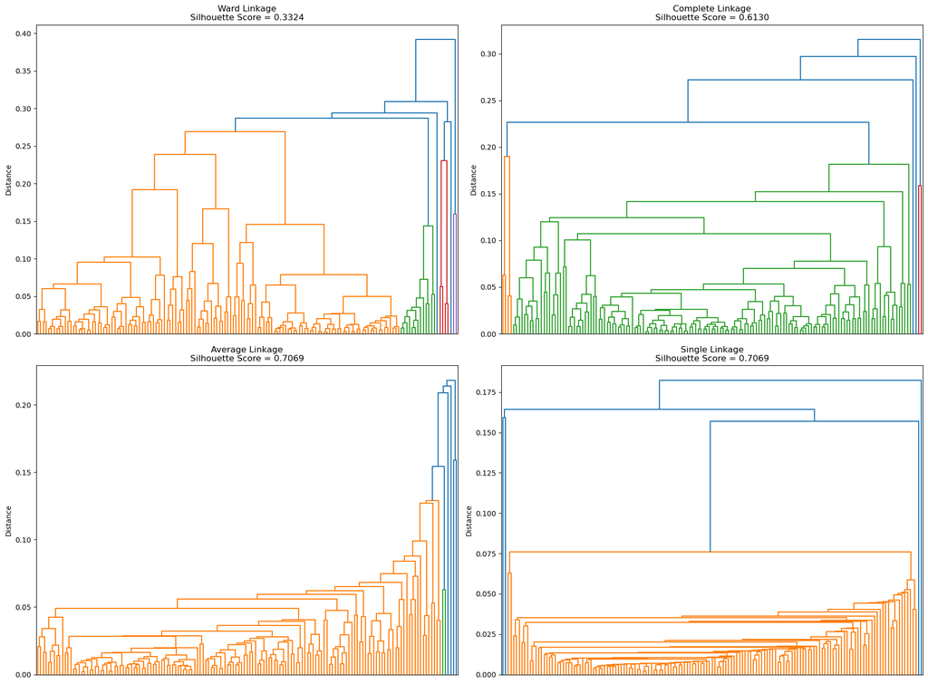

```python
import matplotlib.pyplot as plt
from scipy.cluster.hierarchy import linkage, fcluster, dendrogram
from sklearn.metrics import silhouette_score

df_clean = df.dropna(subset=features).reset_index(drop=True)
sample_rate = 15
X_sampled = pc_coords[::sample_rate]
df_sampled = df_clean.iloc[::sample_rate].reset_index(drop=True)

linkage_methods = ['ward', 'complete', 'average', 'single']
silhouette_scores = {}

plt.figure(figsize=(18, 14))

labels_list = list(df_sampled.index)
for i, method in enumerate(linkage_methods):
    linked = linkage(X_sampled, method=method)
    labels = fcluster(linked, 5, criterion='maxclust')
    score = silhouette_score(X_sampled, labels)
    silhouette_scores[method] = score

    plt.subplot(2, 2, i + 1)
    dendrogram(linked,
               orientation='top',
               distance_sort='descending',
               labels=labels_list,
               show_leaf_counts=False)

    ax = plt.gca()
    for label in ax.get_xticklabels():
        label.set_visible(False)
    for label in ax.get_xticklabels()[::10]:
        label.set_visible(True)
        label.set_rotation(90)
        label.set_fontsize(6)

    plt.title(f"{method.capitalize()} Linkage\nSilhouette Score = {score:.4f}")
    plt.ylabel("Distance")

plt.tight_layout(rect=[0, 0, 1, 0.95])
plt.show()

best_method = 'average'
linked_final = linkage(pc_coords, method=best_method)
final_labels = fcluster(linked_final, 5, criterion='maxclust')
df_clean['Cluster'] = final_labels
```

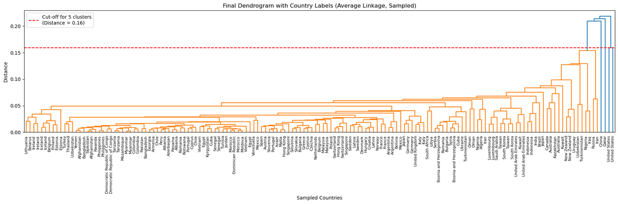

```python
linked_sampled_final = linkage(X_sampled, method=best_method)
cut_distance = linked_sampled_final[-5 + 1, 2]
country_labels = df_sampled['country'].values

plt.figure(figsize=(18, 6))
dendrogram(linked_sampled_final,
           labels=country_labels,
           orientation='top',
           distance_sort='descending',
           leaf_rotation=90,
           leaf_font_size=8,
           color_threshold=cut_distance)
plt.axhline(y=cut_distance, color='red', linestyle='--', label=f'Cut-off for 5 clusters\n(Distance = {cut_distance:.2f})')
plt.title(f"Final Dendrogram with Country Labels ({best_method.capitalize()} Linkage, Sampled)")
plt.xlabel("Sampled Countries")
plt.ylabel("Distance")
plt.legend(loc="upper left")
plt.tight_layout()
plt.show()
```

```python
summary_table = df_clean.groupby('Cluster')['co2'].agg(['mean', 'count']).sort_values(by='mean', ascending=False)
summary_table['Label'] = ['High Emission', 'Moderately High', 'Medium', 'Moderately Low', 'Low Emission']
cluster_label_map = summary_table['Label'].to_dict()
df_clean['Cluster_Label'] = df_clean['Cluster'].map(cluster_label_map)

label_order = {
    "High Emission": 1,
    "Moderately High": 2,
    "Medium": 3,
    "Moderately Low": 4,
    "Low Emission": 5
}

cluster_summary = []
for cluster_id, label in cluster_label_map.items():
    cluster_df = df_clean[df_clean['Cluster'] == cluster_id]
    top_countries = (
        cluster_df
        .sort_values(by='co2', ascending=False)
        .drop_duplicates(subset='country')
        .head(3)['country']
        .tolist()
    )
    avg_co2 = cluster_df['co2'].mean()

    if avg_co2 > 6000:
        criteria = "CO₂ > 6000 Mt"
    elif avg_co2 > 1000:
        criteria = "CO₂ between 1000–6000 Mt"
    elif avg_co2 > 100:
        criteria = "CO₂ between 100–1000 Mt"
    elif avg_co2 > 50:
        criteria = "CO₂ between 50–100 Mt"
    else:
        criteria = "CO₂ < 50 Mt"

    cluster_summary.append({
        'Cluster ID': cluster_id,
        'Cluster Label': label,
        'Label Order': label_order[label],
        'Avg CO₂ Emission (Mt)': f"{avg_co2:.1f}",
        'Criteria': criteria,
        'Top Countries': ', '.join(top_countries)
    })

cluster_summary_df = pd.DataFrame(cluster_summary)\
    .sort_values('Label Order')\
    .drop(columns='Label Order')\
    .reset_index(drop=True)

print("\nCluster Summary with Top Countries:")
display(cluster_summary_df)
```

```
Cluster Summary with Top Countries:
```

|  | Cluster ID | Cluster Label | Avg CO₂ Emission (Mt) | Criteria | Top Countries |
| --- | --- | --- | --- | --- | --- |
| 0 | 1 | High Emission | 8198.0 | CO₂ > 6000 Mt | China |
| 1 | 2 | Moderately High | 5590.6 | CO₂ between 1000–6000 Mt | United States |
| 2 | 4 | Medium | 178.8 | CO₂ between 100–1000 Mt | India, Russia, Japan |
| 3 | 3 | Moderately Low | 75.2 | CO₂ between 50–100 Mt | Qatar |
| 4 | 5 | Low Emission | 39.4 | CO₂ < 50 Mt | Turkmenistan |

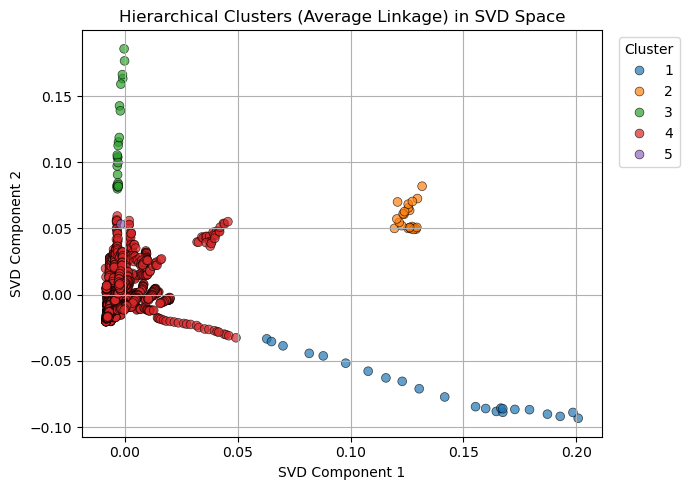

```python
from scipy.cluster.hierarchy import linkage, fcluster

linked = linkage(pc_coords, method='average')
hier_labels = fcluster(linked, 5, criterion='maxclust')

df['hier_cluster'] = hier_labels

plt.figure(figsize=(7,5))
sns.scatterplot(x=pc_coords[:, 0], y=pc_coords[:, 1], hue=hier_labels, palette='tab10', s=40, edgecolor='k', alpha=0.7)
plt.xlabel("SVD Component 1")
plt.ylabel("SVD Component 2")
plt.title("Hierarchical Clusters (Average Linkage) in SVD Space")
plt.legend(title="Cluster", bbox_to_anchor=(1.02,1), loc="upper left")
plt.grid(True)
plt.tight_layout()
plt.show()
```

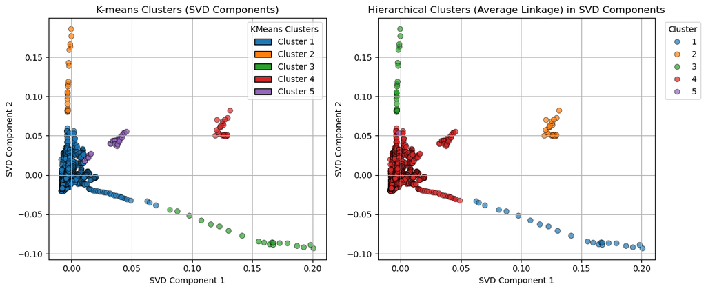

```python
from matplotlib.patches import Patch

plt.figure(figsize=(12, 5))

# KMeans Clusters on SVD Components
plt.subplot(1, 2, 1)
sns.scatterplot(x=pc_coords[:,0], y=pc_coords[:,1], hue=labels, palette='tab10', s=40, edgecolor='k', alpha=0.7)
plt.xlabel("SVD Component 1")
plt.ylabel("SVD Component 2")
plt.title("K-means Clusters (SVD Components)")
plt.legend(handles=legend_elements, title="KMeans Clusters")
plt.grid(True)

# Hierarchical Clusters on SVD Components
plt.subplot(1, 2, 2)
scatter2 = sns.scatterplot(x=pc_coords[:, 0], y=pc_coords[:, 1], hue=hier_labels, palette='tab10', s=40, edgecolor='k', alpha=0.7)
plt.xlabel("SVD Component 1")
plt.ylabel("SVD Component 2")
plt.title("Hierarchical Clusters (Average Linkage) in SVD Components")
plt.legend(title="Cluster", bbox_to_anchor=(1.02,1), loc="upper left")
plt.grid(True)
plt.tight_layout()
plt.show()

plt.tight_layout()
plt.show()
```

```python
comparison_data = {
    'Method': ['SVD + K-means', 'SVD + Average'],
    'Optimal_Clusters': [optimal_k_svd, optimal_k_svd],
    'Silhouette_Score': [
        silhouette_score(pc_coords, labels),
        silhouette_score(pc_coords, hier_labels),
    ]
}

comparison_df = pd.DataFrame(comparison_data)
print("\nClustering Method Comparison:")
print(comparison_df.round(3))
```

```
Clustering Method Comparison:
          Method  Optimal_Clusters  Silhouette_Score
0  SVD + K-means                 5             0.640
1  SVD + Average                 5             0.703
```

```
Confusion Matrix: K-means vs Average Hierarchical (SVD)
```

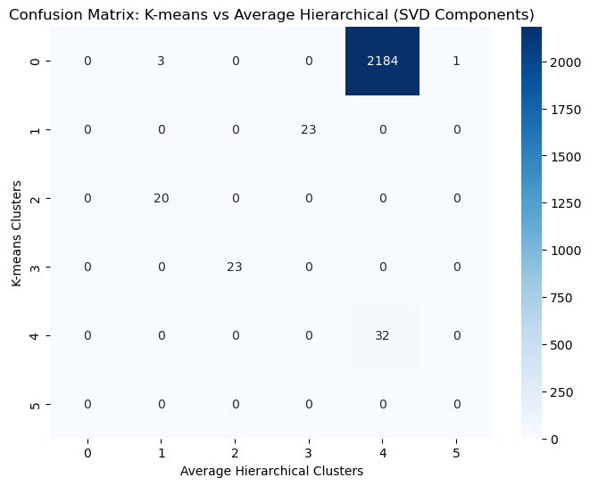

```
Adjusted Rand Index (SVD): 0.774
```

```python
from sklearn.metrics import confusion_matrix
print("\nConfusion Matrix: K-means vs Average Hierarchical (SVD)")
conf_matrix_svd = confusion_matrix(labels, hier_labels)
plt.figure(figsize=(8, 6))
sns.heatmap(conf_matrix_svd, annot=True, fmt='d', cmap='Blues')
plt.title('Confusion Matrix: K-means vs Average Hierarchical (SVD Components)')
plt.xlabel('Average Hierarchical Clusters')
plt.ylabel('K-means Clusters')
plt.show()

# Calculating Adjusted Rand Index score for SVD methods
from sklearn.metrics import adjusted_rand_score
ari_svd = adjusted_rand_score(labels, hier_labels)
print(f"Adjusted Rand Index (SVD): {ari_svd:.3f}")
```

```python
import pandas as pd

# Load your dataset
df = pd.read_csv("Filtered_CO2.csv")

df = df[df['co2'].notna() & (df['co2'] >= 0)]

country_avg_co2 = df.groupby('country')['co2'].mean().reset_index()

def categorize_co2(avg):
    if avg > 6000:
        return 'High Emission'
    elif avg > 1000:
        return 'Moderately High'
    elif avg > 100:
        return 'Medium'
    elif avg > 50:
        return 'Moderately Low'
    else:
        return 'Low'

country_avg_co2['Emission Category'] = country_avg_co2['co2'].apply(categorize_co2)

for category in ['High Emission', 'Moderately High', 'Medium', 'Moderately Low', 'Low']:
    countries = country_avg_co2[country_avg_co2['Emission Category'] == category]['country'].unique()
    print(f"\n{category}:")
    print(", ".join(countries[:5]))
```

```
High Emission:
China

Moderately High:
India, Japan, Russia, United States

Medium:
Algeria, Argentina, Australia, Belgium, Brazil

Moderately Low:
Austria, Bangladesh, Belarus, Chile, Colombia

Low:
Afghanistan, Albania, Armenia, Azerbaijan, Benin
```